# SATAY data analysis pipeline

The workflow is as follow:

1. Prepare workspace
2. Read Fastq file
3. Trim adaptors and low qual. bases
4. align to reference genome
5. attribute every sequence reads to a transposon
6. count the number of transposons and reads per genomic features
7. save output files in bed, wig, bigwig, and csv formats

# 1 Prepare Workspace

## 1.1 Before we start

### 1.1.1 Install Libraries

We need to install the important libraries (must be done once per system) *note that, on linux system, you might need to install the following packages:* *openssl-dev, libxml2-dev and maybe others*

```r
#libraries to install:

install.packages("tidyverse")
install.packages("ggplot2")
install.packages("plyr")
install.packages("BiocManager")
library(BiocManager)

BiocManager::install("Rsamtools")
BiocManager::install("Rbowtie2")
BiocManager::install("ShortRead")
BiocManager::install("BSgenome.Scerevisiae.UCSC.sacCer3", version = "3.8") #We'll use v3.8 throughout for future compatibility
```

### 1.1.2 Loading Libraries

Loading the libraries must be done in each session

```r
#load libraries
library(ggplot2)
library(tidyverse)
library(tcltk)
library(plyr)
library(Rsamtools)
library(Rbowtie2)
library(ShortRead)
library("BSgenome.Scerevisiae.UCSC.sacCer3")
```

### 1.1.3 Declare variables

**First we’ll need to declare important variables**, such as the path for the fastq files and where to store the temporary trimmed fastq file

```r
samplename<-"foobar"                        #This can be anything. It will be used to name the output files


genomepath<- "C:/Users/myuser/yeastgenome/"  #points to the folder where the genome and the genome annotation files are stored
workpath<- "C:/Users/myuser/results/"        #points to the folder in which the results will be saved


tmpfolder<- "C:/Users/myuser/tmp/"        #points to a temporary folder where intermediate data will be temporarily stored.
dir.create(tmpfolder)



fastqFolder <- "C:/Users/myuser/myFastqFolder/" #points to the folder where the fastq Files are saved


#The variables below are generated automatically
trimmed<-paste0(tmpfolder,"/trimmed.fq")
samfile<-paste0(tmpfolder,"/aligned.sam")
setwd(workpath)
bamfile<-paste0(workpath,"/",samplename)

yeastGFF<-paste0(genomepath,"/saccharomyces_cerevisiae_R64-2-1_20150113.gff")
yeastgenome<-paste0(genomepath,"/yeastgenome.fa")
```

### 1.1.4 find NlaIII and DpnII files in the list of fastQ files found in the folder

We use a recursive search and a pattern to distinguish NlaIII and DpnII files. This means that “NlaIII” and “DpnII” must be present in the file name of the fastq files.

```r
fastqfilesNlaIII<-list.files(fastqFolder,"NlaIII.*[.]fastq[.]gz", ignore.case=T, recursive = T)
fastqfilesDpnII<-list.files(fastqFolder,"DpnII.*[.]fastq[.]gz", ignore.case=T, recursive = T)
```

# 2 Reading Fastq File

and

# 3 Trimming

Because reading a whole fastq file uses a lot of memory, we’ll read it piecemeal, trim it and write it on the go.

## 3.1 For the NlaIII library:

```r
#preprocess NLAIII Fastq file and remove adaptors
NlaIII="CATG"
file.remove(trimmed)
for (i in fastqfilesNlaIII){
  stream <- open(FastqStreamer(paste0(fastqFolder,"/",i),100000))
  repeat{
    fq<-yield(stream)
    if (length(fq) == 0)
      +             break

    ########Trimming of adaptors
    vmatchPattern(NlaIII,fq@sread)->matchingReads
    lapply(matchingReads@ends, function(l) l[[1]])->matchingReads
    matchingReads[unlist(lapply(matchingReads, is.null))]<-NA
    unlist(matchingReads)->matchingReads
    narrow(fq, end = matchingReads)->fq


    #######trimming based on quality:
      #### the phred score (here 13) relates to the CLC quality score limit like this:
      #### clcscore=10^(phredscore/-10). for a clcscore of 0.05, phredscore = 13 but 13 won't work
    phredscore="4"

    fq <- trimTailw(fq, 2, phredscore, 2)
    writeFastq(fq, trimmed, "a", compress=FALSE)
  }
  close(stream)
}
```

## 3.2 for the DpnII library,

*we append the DpnII read on the same output file, thus concatenating both datasets:*

```r
#preprocess DpnII Fastq file and remove adaptors

DpnII="GATC"
#file.remove(trimmedDpnII)
for (i in fastqfilesDpnII){
  stream <- open(FastqStreamer(paste0(fastqFolder,"/",i),100000))
  repeat{
    fq<-yield(stream)
    if (length(fq) == 0)
      +             break

    ########Trimming of adaptors
    vmatchPattern(DpnII,fq@sread)->matchingReads
    lapply(matchingReads@ends, function(l) l[[1]])->matchingReads
    matchingReads[unlist(lapply(matchingReads, is.null))]<-NA
    unlist(matchingReads)->matchingReads
    narrow(fq, end = matchingReads)->fq

    #######trimming based on quality:
    fq <- trimTailw(fq, 2, phredscore, 2)
    writeFastq(fq, trimmed, "a", compress=FALSE)
  }
  close(stream)
}
```

# 4 Aligning to reference genome

## 4.1 Load the genome

must be done only once. The files are then written

```r
genome <- BSgenome.Scerevisiae.UCSC.sacCer3
infoseq<-genome@seqinfo
writeBSgenomeToFasta(genome, yeastgenome)
dir.create(paste0(dirname(yeastgenome), "/bowtie2/"))
indexedgenome<-paste0(dirname(yeastgenome), "/bowtie2/indexedgenome")
bowtie2_build(yeastgenome, indexedgenome, overwrite = TRUE)
```

## 4.2 align with Bowtie2

*the version of bowtie shipped in the Rbowtie2 package did not run on my windows machine! I had to download bowtie2-2.3.4 and replace the executable bowtie2-align-s.exe in the Rbowtie directory with the downloaded version.*

### 4.2.1 alignment

**you may want to change the option `--threads`. It is now set to 6, but it may not be best for your setup**

```r
indexedgenome<-paste0(dirname(yeastgenome), "/bowtie2/indexedgenome")
bowtie2(indexedgenome,
        samfile,
        trimmed,
        "--local --threads 6",
        overwrite=TRUE
        )
```

### 4.2.2 convert SAM file to BAM file

and remove SAM file and trimmed reads file (for spce saving purpose)

```r
asBam(samfile,destination = bamfile)
file.remove(samfile)
file.remove(trimmed)
```

## 4.3 read BAM file

We will only get the chromosome, the coordinates, the orientation (flag) and the length of the read. Moreover will filter for reads with quality > than `qual` (meaning the mapping is confident) **There is a stupid glitch: the `asBam`command above does add an `.bam` extension automatically. So we have to add it in our command pointing to the file.**

```r
qual<-5
parameters<-ScanBamParam(what=c("rname", "strand", "pos", "qwidth"), mapqFilter= qual)
bamdata<-scanBam(paste0(bamfile,".bam"), param = parameters)

bamdata[[1]]$strand->orientation
bamdata[[1]]$pos->position
bamdata[[1]]$qwidth->size
bamdata[[1]]$rname->chr

remove(bamdata)
```

### 4.3.1 select reads in + and - orientations

```r
posplus<-as.array(position[(orientation == "+")])
chrplus<-as.factor(chr[(orientation == "+")])
oriplus<-as.factor(orientation[(orientation == "+")])

posminus<-as.array(position[(orientation == "-")])
sizeminus<-as.array(size[(orientation == "-")])
chrminus<-as.factor(chr[(orientation == "-")])
oriminus<-as.factor(orientation[(orientation == "-")])
```

For all reads that are in the `+` orientation, the position is correct. For those in the `-` orientation, the insertion site must be corrected by

### 4.3.2 adding the length of the read to the position

```r
corrpositionminus<-posminus+sizeminus
```

Let’s put everything in a `readcoordinate` data frame and sort it by chromosome, then by coordinate

```r
readcoordinates<-data.frame(
  chrom = fct_c(chrplus,chrminus),
  coord = c(posplus,corrpositionminus),
  strand = fct_c(oriplus, oriminus)
)


readcoordinates<-readcoordinates[
  order(readcoordinates$chrom, readcoordinates$coord),
]
```

**Here the ‘-’ orientation has been translated into `2` while the ‘+’ has been translated into `1`, because it is not a “factor” anymore, it is an “integer”.**

#Remove few reads mapping outside of chromosome bounds This happens because of the extra nt added to ‘-’ oriented reads, and the imprecision of sequences at chromosome ends, but causes problems downstream

```r
len_chr = c(230218,  813184, 316620, 1531933,  576874,
              270161, 1090940, 562643,  439888,  745751,
              666816, 1078177, 924431,  784333, 1091291,
              948066,   85799)
  chr_name = c("chrI",   "chrII",  "chrIII",  "chrIV",  "chrV",
               "chrVI",  "chrVII", "chrVIII", "chrIX",  "chrX",
               "chrXI",  "chrXII", "chrXIII", "chrXIV", "chrXV",
               "chrXVI", "chrmt")

outofbounds<-integer()
for (i in 1:length(len_chr)) {
      outofbounds<-c(outofbounds, which(readcoordinates$chrom == chr_name[i] & readcoordinates$coord > len_chr[i]))
}

readcoordinates<-readcoordinates[-outofbounds,]
```

# 5 Group reads according to their transposon

We’re going to go through each one after the other and if the position is within 2bp of the previous one, we’ll count the reads as being part of the same transposon.

```r
rm(tncoordinates)
tncoordinates<-list()
lvlchrom<-levels(readcoordinates$chrom)


pb<-txtProgressBar(min=0, max = length(readcoordinates$chrom))
#process first read
readcounter<-1
tnnumber<-1
readnumb<-1
tncounter<-1
coord<-readcoordinates$coord[readcounter]
strand<-readcoordinates$strand[readcounter]
readnumb<-1
tncoordinates$chrom[tncounter]<-readcoordinates$chrom[readcounter]
tncoordinates$pos[tncounter]<-readcoordinates$pos[readcounter]
tncoordinates$strand[tncounter]<-readcoordinates$strand[readcounter]


#process further reads
for (readcounter in 2:length(readcoordinates$chrom)) {
      if (abs(readcoordinates$coord[readcounter]-coord)<3 & readcoordinates$strand[readcounter]==strand) {
        readnumb<-readnumb+1
      } else {
        tncoordinates$chrom[tncounter]<-readcoordinates$chrom[readcounter-1]
        tncoordinates$coord[tncounter]<-as.integer(mean(readcoordinates$coord[(readcounter-readnumb):(readcounter-1)]))
        tncoordinates$strand[tncounter]<-readcoordinates$strand[readcounter-1]
        tncoordinates$readnumb[tncounter]<-readnumb

        readnumb<-1
        tncounter<-tncounter+1
        coord<-readcoordinates$coord[readcounter]
        strand<-readcoordinates$strand[readcounter]
      }
  setTxtProgressBar(pb,readcounter)

}
```

*cleanup time!*

```r
rm(pb)
rm(parameters)
rm(chr)
rm(chrminus)
rm(chrplus)
rm(coord)
rm(corrpositionminus)
rm(fastqFilesDpnII)
rm(fastqFilesNlaIII)
rm(trimmed)
rm(orientation)
rm(oriminus)
rm(oriplus)
rm(position)
rm(posminus)
rm(posplus)
rm(qual)
rm(readcounter)
rm(readnumb)
rm(samfile)
rm(size)
rm(sizeminus)
rm(strand)
rm(tncounter)
rm(tnnumber)
rm(outofbounds)
```

## 5.1 prepare chromosomal features from gff file

extract `gene`and `centromere` into separate objects.

```r
#read GFF

gffdata<-import.gff(yeastGFF)
GFF<-list()
GFF$type<-gffdata@elementMetadata@listData$type
GFF$name<-gffdata@elementMetadata@listData$Name
GFF$gene<-gffdata@elementMetadata@listData$gene
GFF$start<-gffdata@ranges@start
GFF$end<-gffdata@ranges@start+gffdata@ranges@width




read.delim(yeastGFF, header=F, comment.char="#", skip = 18, nrows = 23058) -> tmpgff
gff<-plyr::rename(tmpgff, c("V1" = "chrom", "V2"="source", "V3"="type","V4"="start","V5"="end","V7"="strand"))
gff$chrom<-as.character(gff$chrom)
gff$chrom<-factor(gff$chrom, levels = lvlchrom)

GFF$chrom<-gff$chrom
GFF$strand<-gff$strand

GFF<-data.frame(GFF)

GFF[GFF$type=="gene",]->gene
knowngene<-which(gene$gene!="NA")
gene$name<-as.character(gene$name)
gene$name[knowngene]<-as.character(gene$gene[knowngene])



GFF[GFF$type=="centromere",]->centromere
```

## 5.2 (optional) plot transposon density along chromosomes

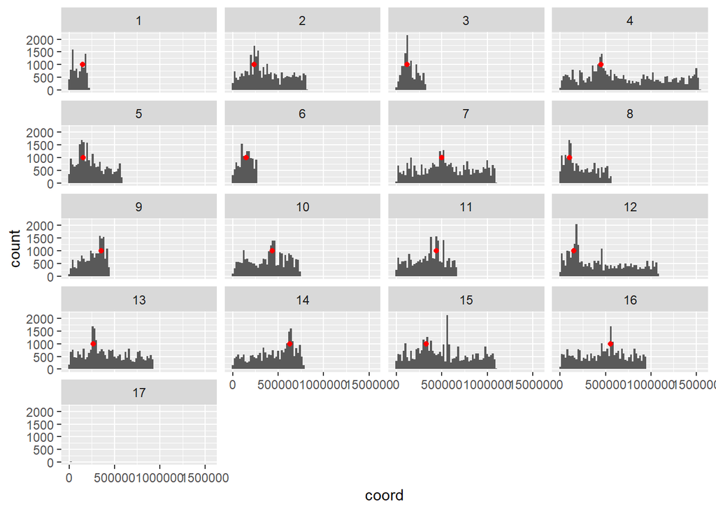

```r
centromereplot<-list()
centromereplot$chrom<-(1:16)
centromereplot$coord<-(centromere$start+centromere$end)/2

ggplot()+
  geom_histogram(data=data.frame(tncoordinates), aes(x=coord), binwidth=20000)+
  geom_point(data = data.frame(centromereplot), aes(x=coord, y=1000),color="red")+
  facet_wrap(~ chrom, nrow = 5)
```

# 6 Count number of transposons and of reads per chromosomal features

```r
tnpergene<-numeric()
readpergene<-numeric()
readpergenecrude<-numeric()
pb<-txtProgressBar(min=0, max = length(gene$chrom))

for (i in 1:length(gene$start)) {
  tnindex<-which((tncoordinates$coord > gene$start[i]) &
    (tncoordinates$coord < gene$end[i]) &
    (tncoordinates$chrom == as.numeric(gene$chrom[i])))

  tnpergene[i]<-length(tnindex)

  if (length(tnindex)>0) {
    readpergene[i]<-sum(tncoordinates$readnumb[tnindex])-max(tncoordinates$readnumb[tnindex])
  } else {
    readpergene[i]<-0
  }

  readpergenecrude[i]<-sum(tncoordinates$readnumb[tnindex])

    setTxtProgressBar(pb,i)
}
```

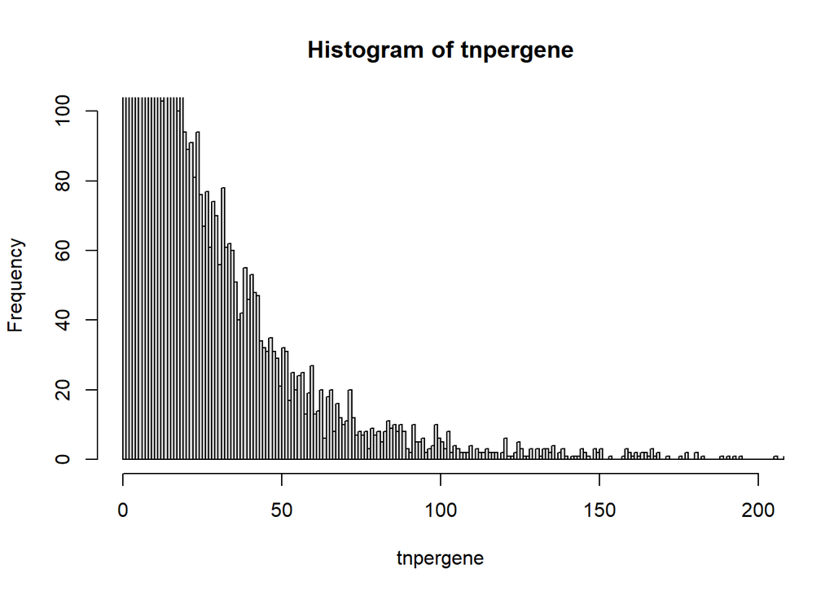

```r
hist(tnpergene, breaks=seq(min(tnpergene),max(tnpergene)),xlim=c(0,200),ylim=c(0,100))
```

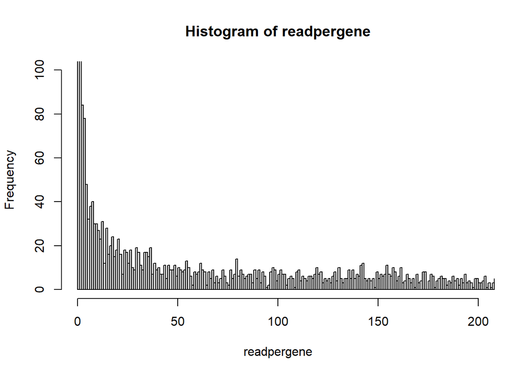

```r
hist(readpergene, breaks=seq(min(readpergene),max(readpergene)),xlim=c(0,200), ylim=c(0,100))
```

```r
# ggplot()+
#   geom_point(mapping=aes(x=tnpergene, y=readpergene, color=gene$chrom))+
#   xlim(0,500)+
#   ylim(0,5000)
```

# 7 write output to files

## 7.1 write a big bed file

```r
bedfile<-paste0(bamfile,".bed")
headerline<-paste0("track name=\"",basename(bamfile),"\" useScore=1")



bed<-list()
bed$chrom<-plyr::mapvalues(tncoordinates$chrom, as.character(1:17), lvlchrom)
bed$start<-format(tncoordinates$coord, scientific = FALSE)
bed$end<-format((tncoordinates$coord+1), scientific = FALSE)
bed$desc<-paste(replicate(length(bed$start),"."))
bed$score<-tncoordinates$readnumb*10+100
bed<-data.frame(bed)



writeLines(headerline, con = bedfile)
write.table(bed,bedfile, quote =FALSE, row.names = FALSE, col.names =FALSE, append=TRUE)

readLines(bedfile, n=10)
```

```
##  [1] "track name=\"MiMB\" useScore=1" "chrI      42      43 . 110"
##  [3] "chrI      69      70 . 210"     "chrI      77      78 . 580"
##  [5] "chrI      79      80 . 120"     "chrI      91      92 . 110"
##  [7] "chrI      94      95 . 120"     "chrI     101     102 . 360"
##  [9] "chrI     111     112 . 560"     "chrI     115     116 . 110"
```

## 7.2 write a wig file

It is necessary to have only one transposon at any given place. If two (one `+` and one `-`) map at the same place, both must be summed

```r
wigfile<-paste0(bamfile,".wig")
headerline<-paste0("track type=wiggle_0 maxHeightPixels=60 name=\"",basename(bamfile),"\"")


wig<-list()
wig$chrom<-plyr::mapvalues(tncoordinates$chrom, as.character(1:17), lvlchrom)
wig$coord<-format(tncoordinates$coord, scientific = FALSE)
wig$score<-tncoordinates$readnumb
wig<-data.frame(wig)

wigdup<-which(duplicated(wig[,1:2]))
wig[(wigdup-1),3]<-wig[(wigdup-1),3]+wig[(wigdup),3]
wig<-wig[-wigdup,]
wigchrom<-wig$chrom
wig$chrom<-NULL

writeLines(headerline, con = wigfile)
for (i in lvlchrom) {

  write(paste0("variableStep chrom=",i), file = wigfile, append=TRUE)
  write.table(wig[
    wigchrom == i
  ,],
  wigfile, quote =FALSE, row.names = FALSE, col.names =FALSE, append=TRUE)
}

readLines(wigfile, n=10)
```

```
##  [1] "track type=wiggle_0 maxHeightPixels=60 name=\"MiMB\""
##  [2] "variableStep chrom=chrI"
##  [3] "     42 1"
##  [4] "     69 11"
##  [5] "     77 48"
##  [6] "     79 2"
##  [7] "     91 1"
##  [8] "     94 2"
##  [9] "    101 26"
## [10] "    111 46"
```

## 7.3 write a pergene file

```r
pergenefile<-paste0(bamfile,"_pergene.txt")
headerline<-paste("gene_name", "number_of_transposon_per_gene","number_of_read_per_gene")

pergene<-list()
pergene$name<-gene$name
pergene$tn<-tnpergene
pergene$read<-readpergene
pergene<-data.frame(pergene)

writeLines(headerline, con = pergenefile)
write.table(pergene,pergenefile, quote =FALSE, row.names = FALSE, col.names =FALSE, append=TRUE)


readLines(pergenefile, n=10)
```

```
##  [1] "gene_name number_of_transposon_per_gene number_of_read_per_gene"
##  [2] "YAL069W 45 1209"
##  [3] "YAL068W-A 14 261"
##  [4] "PAU8 2 1"
##  [5] "YAL067W-A 6 139"
##  [6] "SEO1 45 1975"
##  [7] "YAL066W 17 131"
##  [8] "YAL065C 6 14"
##  [9] "YAL064W-B 5 13"
## [10] "TDA8 10 208"
```